# Assigment 3

```r
library(dplyr)
library(tidyverse)
#read the joined student alcohol consumption data into R from url (just in case that everything is correct)
library(readr)
alc <- read_csv("https://raw.githubusercontent.com/KimmoVehkalahti/Helsinki-Open-Data-Science/master/datasets/alc.csv", show_col_types=FALSE)

#print out the names of the variables in the data
colnames (alc)
```

```
##  [1] "school"     "sex"        "age"        "address"    "famsize"
##  [6] "Pstatus"    "Medu"       "Fedu"       "Mjob"       "Fjob"
## [11] "reason"     "guardian"   "traveltime" "studytime"  "schoolsup"
## [16] "famsup"     "activities" "nursery"    "higher"     "internet"
## [21] "romantic"   "famrel"     "freetime"   "goout"      "Dalc"
## [26] "Walc"       "health"     "failures"   "paid"       "absences"
## [31] "G1"         "G2"         "G3"         "alc_use"    "high_use"
```

```r
#N sex
alc %>% group_by(sex) %>% summarise(count = n())
```

```
## # A tibble: 2 × 2
##   sex   count
##   <chr> <int>
## 1 F       195
## 2 M       175
```

```r
#N age
alc %>% group_by(age) %>% summarise(count = n())
```

```
## # A tibble: 7 × 2
##     age count
##   <dbl> <int>
## 1    15    81
## 2    16   102
## 3    17    97
## 4    18    77
## 5    19    11
## 6    20     1
## 7    22     1
```

## 3.1 The description of the data

This data approach student achievement in secondary education of two Portuguese schools. The data attributes include student grades, demographic, social and school related features (35 variables) and it was collected by using school reports and questionnaires. Two data sets were first provided regarding the performance in two distinct subjects: Mathematics (mat) and Portuguese language (por). In this report I used a joined data set, where I made following adjustment: the grade variables were combined by averaging in math and Portuguese, ‘alc_use’ outcome was an average of workday alcohol consumption (numeric: from 1 - very low to 5 - very high) and weekend alcohol consumption (numeric: from 1 - very low to 5 - very high), and ‘hig_use’ outcome provide information if alc use was higher than 2. There were 370 participants in the study, of which 195 were females. Age range was from 15 to 22 years.

## 3.2 Personal hypothesis about the relationships of outcomes with alcohol consumption

I chose the variables of sex, final grade, number of school absences and current health status, to study their relationships to high/low alcohol consumption. My personal hypothesis were that 1) males have higher alcohol consumption than females, as well as 2) lower final grade, 3) higher number of school absences and 4) lower health status are predicted higher consumption.

## 3.3 The distribuiton of the chosen variables and their relationships with alcohol consumption

```r
#sex
#high use as another grouping variable
alc %>% group_by(sex, high_use) %>% summarise(count = n())
```

[output not shown]

```
## # A tibble: 4 × 3
## # Groups:   sex [2]
##   sex   high_use count
##   <chr> <lgl>    <int>
## 1 F     FALSE      154
## 2 F     TRUE        41
## 3 M     FALSE      105
## 4 M     TRUE        70
```

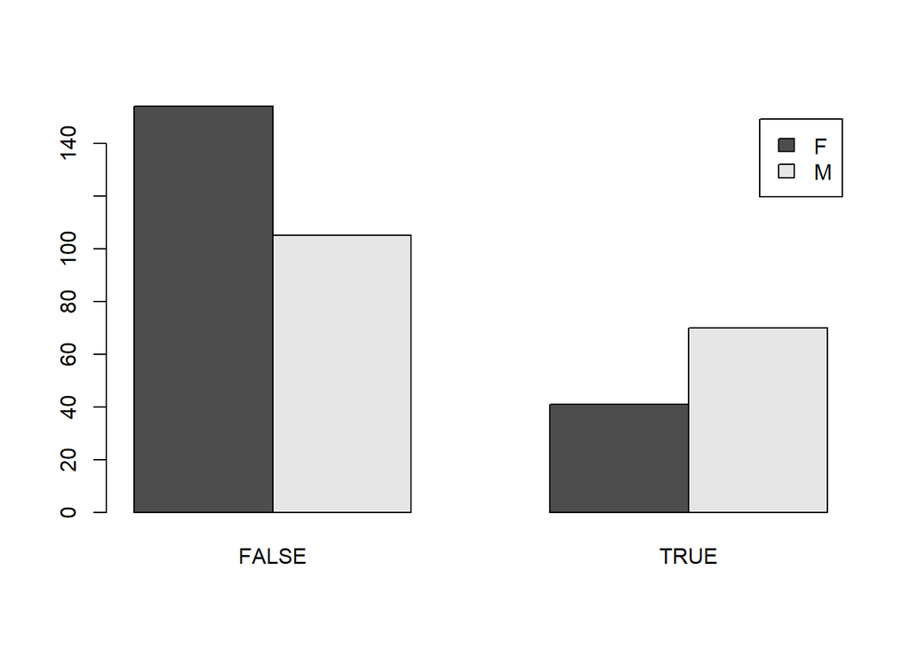

```r
# draw a bar plot of high_use by sex
attach(alc)
counts <- table(sex, high_use)
 barplot(counts,beside=T,legend=c('F','M'))
```

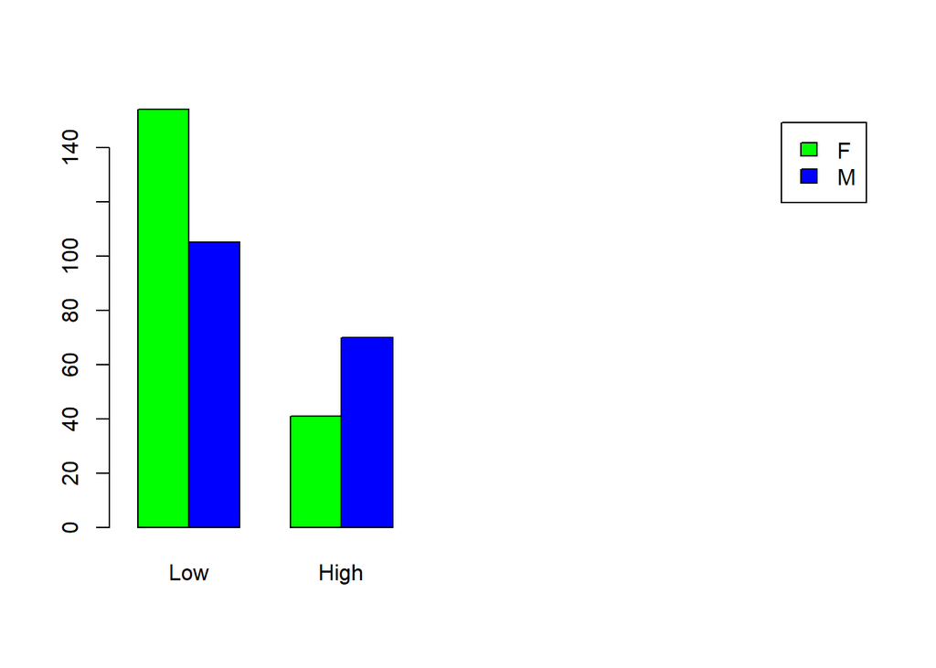

```r
 barplot(counts,col=c('green','blue'),
         names.arg=c('Low', 'High'),
       beside=T,legend=c('F','M'), xlim=c(1,15))
```

By sex, males have more often high alcohol consumption than females (Male N = 70, Female N = 41). This relationship is illustrated in Barplot.

```r
#final grade

#means of the grades of the student
alc %>% group_by(high_use) %>% summarise(mean_grade = mean(G3))
```

```
## # A tibble: 2 × 2
##   high_use mean_grade
##   <lgl>         <dbl>
## 1 FALSE          11.8
## 2 TRUE           10.9
```

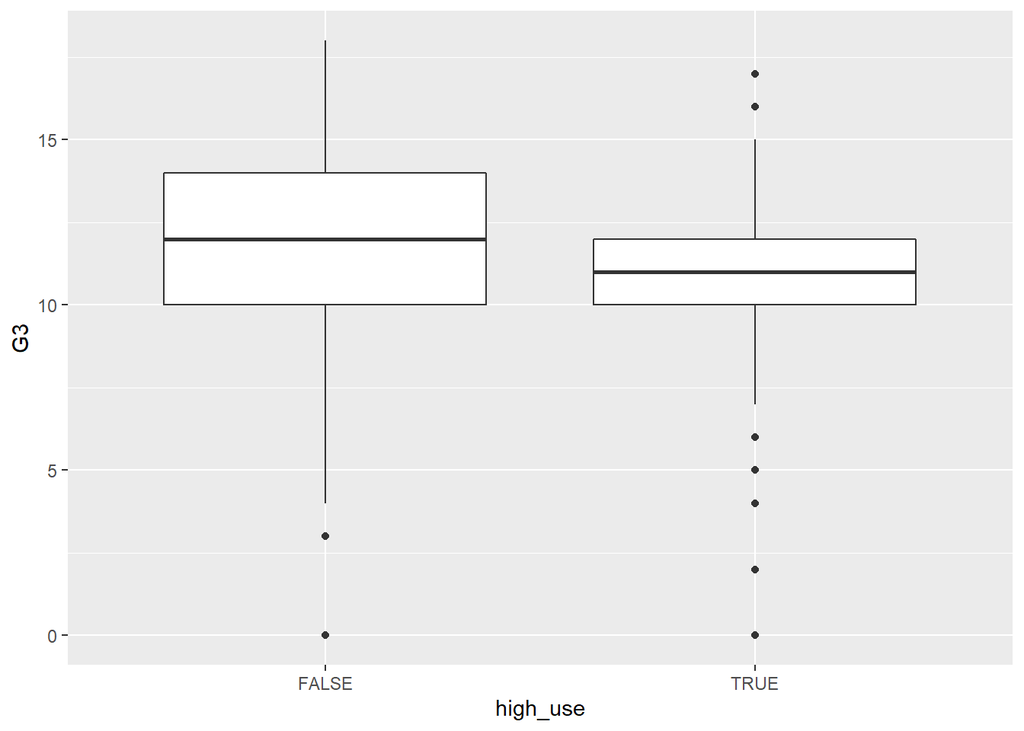

```r
#boxplot
alc %>% ggplot(aes(x = high_use, y = G3)) +
  geom_boxplot()
```

```r
#means of the grades of the student by gender
alc %>% group_by(sex, high_use) %>% summarise(mean_grade = mean(G3))
```

[output not shown]

```
## # A tibble: 4 × 3
## # Groups:   sex [2]
##   sex   high_use mean_grade
##   <chr> <lgl>         <dbl>
## 1 F     FALSE          11.4
## 2 F     TRUE           11.8
## 3 M     FALSE          12.3
## 4 M     TRUE           10.3
```

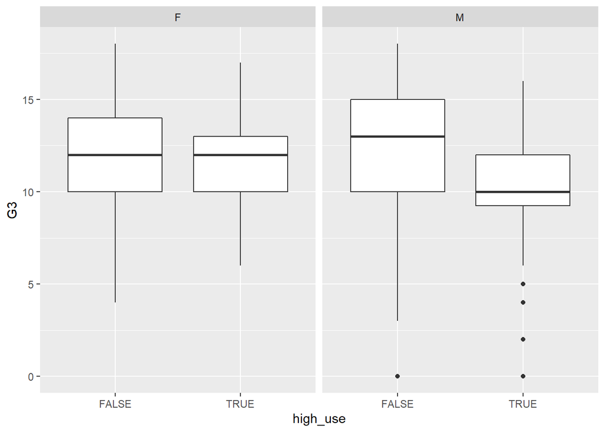

```r
plot1 = ggplot(alc, aes(x=high_use, y=G3)) + geom_boxplot() + facet_grid(~sex)
plot1
```

The descriptive statistics by grade show that mean of grade is higher in low alcohol consumption group (11.80 vs 10.86). The mean grades varied by gender; so that in males the differences in means was larger between the high and low consumption groups as compared to females. These results are illustrated in boxplots above.

```r
#school absences

#means of the absences of the student
alc %>% group_by(high_use) %>% summarise(mean_absences = mean(absences))
```

```
## # A tibble: 2 × 2
##   high_use mean_absences
##   <lgl>            <dbl>
## 1 FALSE             3.71
## 2 TRUE              6.38
```

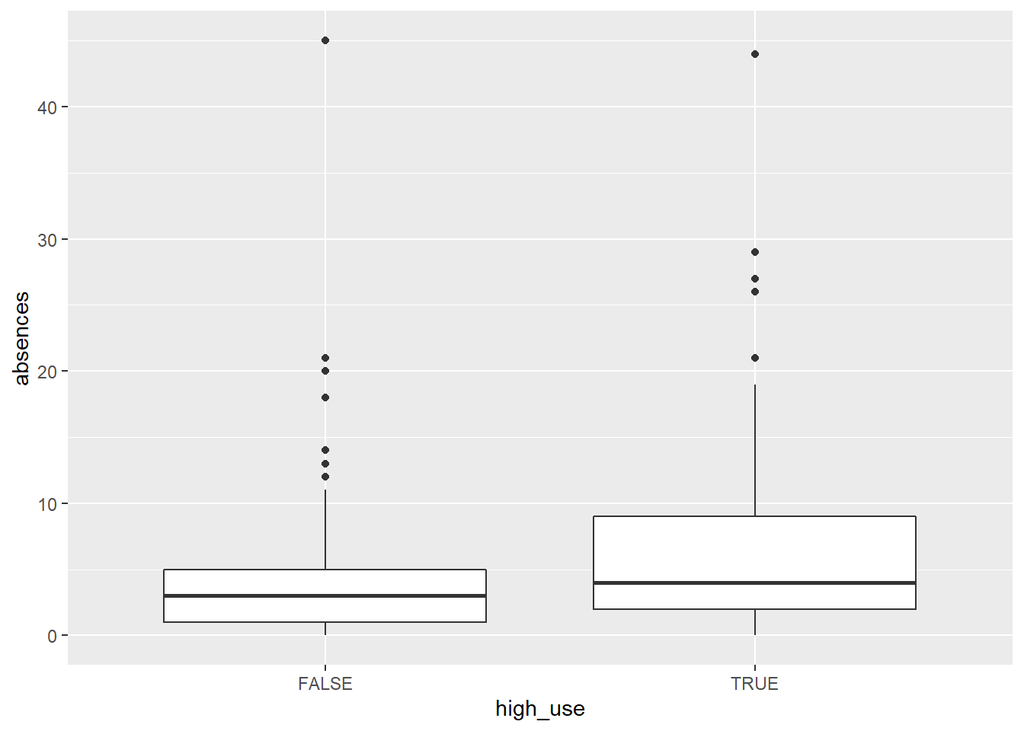

```r
#boxplot
alc %>% ggplot(aes(x = high_use, y = absences)) +
  geom_boxplot()
```

```r
#means of absences of the student by gender
alc %>% group_by(sex, high_use) %>% summarise(mean_grade = mean(absences))
```

[output not shown]

```
## # A tibble: 4 × 3
## # Groups:   sex [2]
##   sex   high_use mean_grade
##   <chr> <lgl>         <dbl>
## 1 F     FALSE          4.25
## 2 F     TRUE           6.85
## 3 M     FALSE          2.91
## 4 M     TRUE           6.1
```

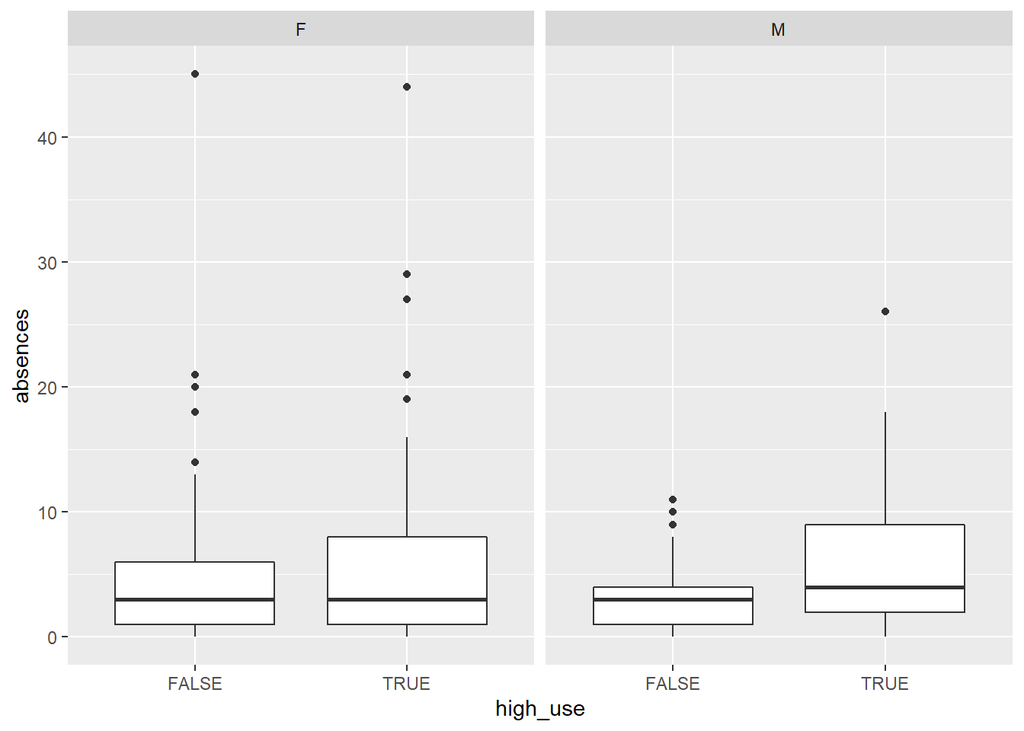

```r
plot2 = ggplot(alc, aes(x=high_use, y=absences)) + geom_boxplot() + facet_grid(~sex)
plot2
```

By school absences, more absences were found in high use group (means: 6.37 vs 3.71). In males the mean difference of school absences was larger between the low and high alcohol consumption groups than in females. However, females with high consumption had more absences than males with high consumption.

```r
#health

#means of current health status of the student
alc %>% group_by(high_use) %>% summarise(mean_health = mean(health))
```

```
## # A tibble: 2 × 2
##   high_use mean_health
##   <lgl>          <dbl>
## 1 FALSE           3.49
## 2 TRUE            3.73
```

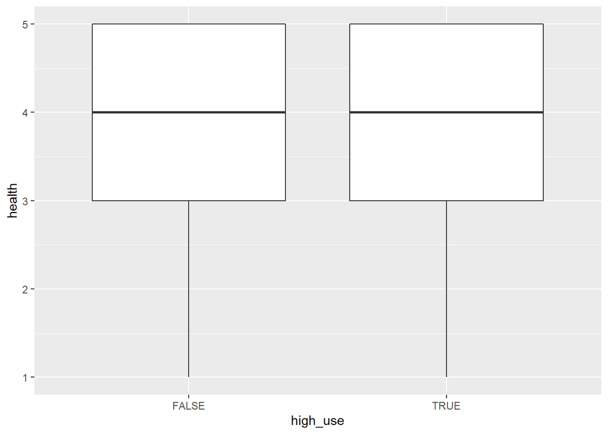

```r
#boxplot
alc %>% ggplot(aes(x = high_use, y = health)) +
  geom_boxplot()
```

```r
#means of health status of the student by gender
alc %>% group_by(sex, high_use) %>% summarise(mean_health = mean(health))
```

[output not shown]

```
## # A tibble: 4 × 3
## # Groups:   sex [2]
##   sex   high_use mean_health
##   <chr> <lgl>          <dbl>
## 1 F     FALSE           3.37
## 2 F     TRUE            3.39
## 3 M     FALSE           3.67
## 4 M     TRUE            3.93
```

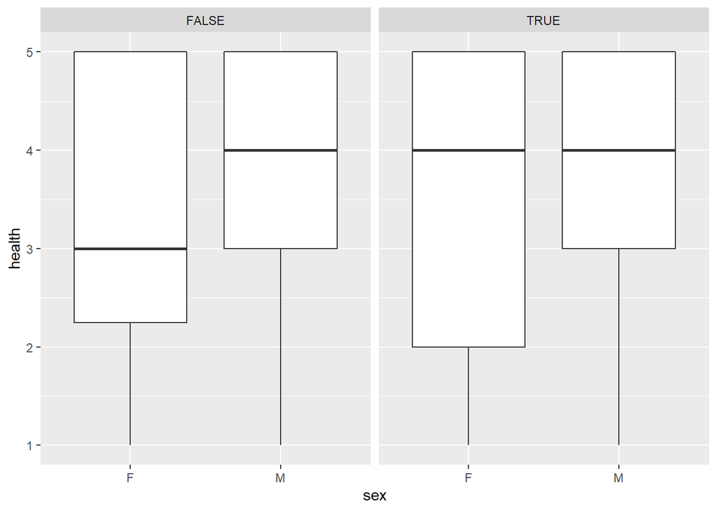

```r
plot3 = ggplot(alc, aes(x=sex, y=health)) + geom_boxplot() + facet_grid(~high_use)
plot3
```

## 3.4 Logistic regression

```r
#model1

# find the model with glm()
model1 <- glm(high_use ~ G3 + absences + sex + health, data = alc, family = "binomial")

# print out a summary of the model
summary(model1)
```

```
##
## Call:
## glm(formula = high_use ~ G3 + absences + sex + health, family = "binomial",
##     data = alc)
##
## Deviance Residuals:
##     Min       1Q   Median       3Q      Max
## -2.2867  -0.8513  -0.6097   1.0669   2.1530
##
## Coefficients:
##             Estimate Std. Error z value Pr(>|z|)
## (Intercept) -1.20679    0.58419  -2.066   0.0389 *
## G3          -0.07619    0.03680  -2.070   0.0384 *
## absences     0.09262    0.02333   3.970 7.19e-05 ***
## sexM         1.02053    0.24766   4.121 3.78e-05 ***
## health       0.06783    0.08880   0.764   0.4450
## ---
## Signif. codes:  0 '***' 0.001 '**' 0.01 '*' 0.05 '.' 0.1 ' ' 1
##
## (Dispersion parameter for binomial family taken to be 1)
##
##     Null deviance: 452.04  on 369  degrees of freedom
## Residual deviance: 410.38  on 365  degrees of freedom
## AIC: 420.38
##
## Number of Fisher Scoring iterations: 4
```

```r
# print out the coefficients of the model
matrix_coef <- summary(model1)$coefficients
matrix_coef
```

```
##                Estimate Std. Error    z value     Pr(>|z|)
## (Intercept) -1.20678611 0.58419346 -2.0657303 3.885396e-02
## G3          -0.07619428 0.03680458 -2.0702387 3.842999e-02
## absences     0.09262464 0.02333255  3.9697599 7.194508e-05
## sexM         1.02053470 0.24766087  4.1206942 3.777325e-05
## health       0.06782637 0.08880294  0.7637853 4.449952e-01
```

```r
# compute odds ratios (OR)
OR1 <- coef(model1) %>% exp

# compute confidence intervals (CI)
CI1 <- confint(model1) %>% exp()
# print out the odds ratios with their confidence intervals
cbind(OR1, CI1)
```

```
##                   OR1      2.5 %    97.5 %
## (Intercept) 0.2991572 0.09342207 0.9282541
## G3          0.9266362 0.86143669 0.9956498
## absences    1.0970499 1.05023715 1.1509892
## sexM        2.7746780 1.71811644 4.5452414
## health      1.0701795 0.90040767 1.2764711
```

```r
model2 <- glm(high_use ~ G3 + absences + health + sex -1, data = alc, family = "binomial")

# print out a summary of the model
summary(model2) #no intercept model
```

```
##
## Call:
## glm(formula = high_use ~ G3 + absences + health + sex - 1, family = "binomial",
##     data = alc)
##
## Deviance Residuals:
##     Min       1Q   Median       3Q      Max
## -2.2867  -0.8513  -0.6097   1.0669   2.1530
##
## Coefficients:
##          Estimate Std. Error z value Pr(>|z|)
## G3       -0.07619    0.03680  -2.070   0.0384 *
## absences  0.09262    0.02333   3.970 7.19e-05 ***
## health    0.06783    0.08880   0.764   0.4450
## sexF     -1.20679    0.58419  -2.066   0.0389 *
## sexM     -0.18625    0.59610  -0.312   0.7547
## ---
## Signif. codes:  0 '***' 0.001 '**' 0.01 '*' 0.05 '.' 0.1 ' ' 1
##
## (Dispersion parameter for binomial family taken to be 1)
##
##     Null deviance: 512.93  on 370  degrees of freedom
## Residual deviance: 410.38  on 365  degrees of freedom
## AIC: 420.38
##
## Number of Fisher Scoring iterations: 4
```

```r
matrix_coef2 <- summary(model2)$coefficients
matrix_coef2
```

```
##             Estimate Std. Error    z value     Pr(>|z|)
## G3       -0.07619428 0.03680458 -2.0702387 3.842999e-02
## absences  0.09262464 0.02333255  3.9697599 7.194508e-05
## health    0.06782637 0.08880294  0.7637853 4.449952e-01
## sexF     -1.20678611 0.58419346 -2.0657303 3.885396e-02
## sexM     -0.18625141 0.59609939 -0.3124503 7.546984e-01
```

```r
# compute odds ratios (OR)
OR2 <- coef(model2) %>% exp

# compute confidence intervals (CI)
CI2 <- confint(model2) %>% exp()
# print out the odds ratios with their confidence intervals
cbind(OR2, CI2)
```

```
##                OR2      2.5 %    97.5 %
## G3       0.9266362 0.86143669 0.9956498
## absences 1.0970499 1.05023715 1.1509892
## health   1.0701795 0.90040767 1.2764711
## sexF     0.2991572 0.09342207 0.9282541
## sexM     0.8300649 0.25579031 2.6667851
```

## 3.5 Predictive power of the model

```r
library(readr)
library(dplyr)
library(boot)
```

```r
library(ggplot2)

# fit the model with outcomes of statistically significant relationships
model1 <- glm(high_use ~ G3 + absences + sex, data = alc, family = "binomial")

# predict() the probability of high_use
probabilities <- predict(model1, type = "response")

library(dplyr)
# add the predicted probabilities to 'alc'
alc <- mutate(alc, probability = probabilities)

# use the probabilities to make a prediction of high_use
alc <- mutate(alc, prediction = probability > 0.5)


# tabulate the target variable versus the predictions
table(high_use = alc$high_use, prediction = alc$prediction)
```

```
##         prediction
## high_use FALSE TRUE
##    FALSE   248   11
##    TRUE     83   28
```

```r
#table for probabilities
table(high_use = alc$high_use, prediction = alc$prediction) %>% prop.table()
```

```
##         prediction
## high_use      FALSE       TRUE
##    FALSE 0.67027027 0.02972973
##    TRUE  0.22432432 0.07567568
```

```r
#add margins
table(high_use = alc$high_use, prediction = alc$prediction) %>% prop.table() %>% addmargins()
```

```
##         prediction
## high_use      FALSE       TRUE        Sum
##    FALSE 0.67027027 0.02972973 0.70000000
##    TRUE  0.22432432 0.07567568 0.30000000
##    Sum   0.89459459 0.10540541 1.00000000
```

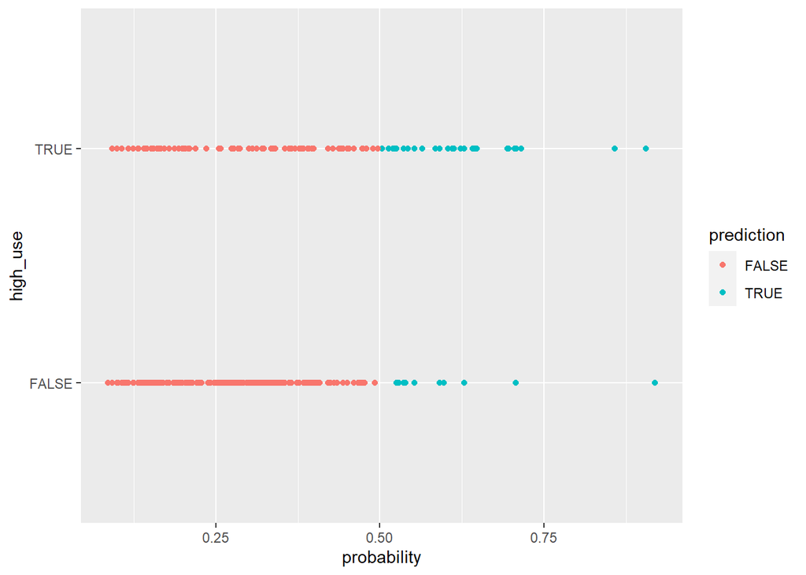

```r
#plot
library(ggplot2)
g2 <- ggplot(alc, aes(x = probability, y = high_use, col = prediction))
g2 + geom_point()
```

```r
# define a loss function (average prediction error)
loss_func <- function(class, prob) {
  n_wrong <- abs(class - prob) > 0.5
  mean(n_wrong)
}

# call loss_func to compute the average number of wrong predictions in the (training) data
loss_func(class = alc$high_use, prob = alc$probability)
```

```
## [1] 0.2540541
```

The total proportion of inaccurately classified individual i.e., the training error is 0.25 for the model. Performance of the the model is similar than simple guessing strategy.